# How rOpenSci performs peer-review

https://github.com/maurolepore/ropensci-review

## Outline

- Introduction
  - About you and us
  - Why this process, and why this talk?
- Two crucial components
  - The way we communicate.
  - The way we build and review software.
- Wrap up
  - Takeaways.
  - Questions and comments.

## Introduction

## About you and us

About you:

- You’re curious about rOpenSci’s review process.
- You may want to author, review, or edit an R package for rOpenSci.

## About you and us

About us:

*Mauro:*

- I build tools to support research in green finance.
- Before I was a biologist.
- I joined rOpenSci in 2018 and played different roles.

*Noam:*

- I am a disease ecologist that works with modeling and field teams
- I’ve worked with rOpenSci since 2014, primarily doing peer-review editorial work
- I’ve been Executive Director for < 3 weeks!

## [Why peer-review?](https://github.com/ropensci/software-review?tab=readme-ov-file#why-and-how-submit-your-package-to-ropensci)

- Drive adoption of best practices and standards
- Increase quality in the long tail of applications
- Build a community of practice

## Drive adoption of best practices and standards

*Some quotes from authors and reviewers:*

> “The review process taught me a lot about different tools available for making my code more robust and resilient to future changes.”

> “I learn a lot from closely reading other people’s code and it is hard to do when I’m not forced to review so closely.”

> “I really love the rOpenSci pacakage review process, especially its interactivity and how much you can learn from others.”

## Increase quality in the long tail of applications

The long tail: monthly downloads of all CRAN packages

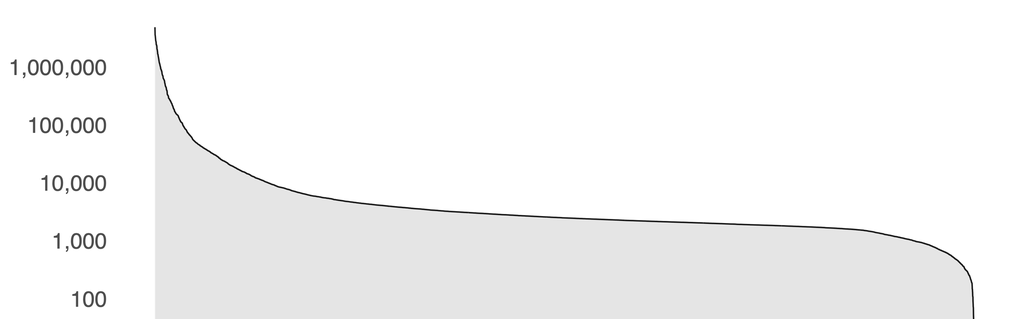

## Increase quality in the long tail of applications

[figure not shown]

## Build a community of practice

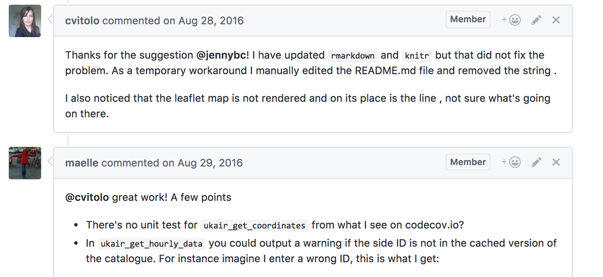

## This was something of an accident!

rOpenSci evolved from

- A group of people who wrote R packages, to
- A group of people who manageed a lot of R packages, and realized we needed review, to
- A group of people who reviewed R packages, and realized we needed a process, to
- A group of people managed a review process, and realized *we needed a community.*

## Why this talk?

### The process is complex and can feel overwhelming

The process is complex and can feel overwhelming.

This talk:

- Highlights the most important materials.
- Shows you where you can find the rest.
- Gives you the chance to ask questions.

## Two crucial components

- The way we communicate: [Code of conduct](https://ropensci.org/code-of-conduct/).
- The way we build and review software: [“Devguide”](https://devguide.ropensci.org/).

> “[Helping to improve software] in a kind and respectful way is just as important as the technical aspect”.  
> – Yanina Bellini Saibene

## Be kind and respectful

[Example of a kind and respectful reviewer’s response](https://github.com/ropensci/software-review/issues/577#issuecomment-1494333794).

> “It’s like when I hold the door open for someone.”  
> “Even when someone volunteers their time, there is a cost of their time and effort.”  
> – [Setting expectations for open source participation](https://snarky.ca/setting-expectations-for-open-source-participation/amp/)

## Be kind and respectful

### [Example of a kind and respectful reviewer’s response](https://github.com/ropensci/software-review/issues/577#issuecomment-1494333794)

> “It’s like when I hold the door open for someone.”

> “Even when someone volunteers their time, there is a cost of their time and effort.”

> – [Setting expectations for open source participation](https://snarky.ca/setting-expectations-for-open-source-participation/amp/)

## The way we build and review software

Guide for authors

- [Package categories in scope for rOpenSci review](https://devguide.ropensci.org/softwarereview_policies.html#package-categories).
- [Guide to building a package](https://devguide.ropensci.org/building.html).
- [Guide to submitting a package](https://devguide.ropensci.org/authors-guide.html).
- [Choose between different types of submission](https://github.com/ropensci/software-review/issues/new/choose).

Other guides, templates, and tools

- [Guide for reviewers](https://devguide.ropensci.org/reviewerguide.html) and [editors](https://devguide.ropensci.org/editorguide.html).
- [Template for reviewers](https://devguide.ropensci.org/reviewtemplate.html) and [editors](https://devguide.ropensci.org/editortemplate.html).
- [Bot commands](https://devguide.ropensci.org/bot_cheatsheet.html).

## Wrap up

## Takeaways

- Be kind and respectful.
- The process is complex but you’ll find lots of help.

## Questions and comments?

Thank you!

Mauro | maurolepore@gmail.com